# VSB Power Line Fault Detection (Kaggle Case Study)

Link to the Dataset: https://www.kaggle.com/competitions/vsb-power-line-fault-detection/overview

### Problem Description

Faults in electric transmission lines can lead to a destructive phenomenon called partial discharge. If left alone, partial discharges can damage equipment to the point that it stops functioning entirely. Your challenge is to detect partial discharges so that repairs can be made before any lasting harm occurs.

Each signal contains 800,000 measurements of a power line's voltage, taken over 20 milliseconds. As the underlying electric grid operates at 50 Hz, this means each signal covers a single complete grid cycle. The grid itself operates on a 3-phase power scheme, and all three phases are measured simultaneously.

### File Descriptions

1. metadata_[train/test].csv
- id_measurement: the ID code for a trio of signals recorded at the same time.
- signal_id: the foreign key for the signal data. Each signal ID is unique across both train and test, so the first ID in train is '0' but the first ID in test is '8712'.
- phase: the phase ID code within the signal trio. The phases may or may not all be impacted by a fault on the line.
- target: 0 if the power line is undamaged, 1 if there is a fault.
2. [train/test].parquet - The signal data. Each column contains one signal; 800,000 int8 measurements as exported with pyarrow.parquet version 0.11.

### Objective

Detect partial discharge patterns in power line signals using ML classifiers. Reduce maintenance costs and prevent outages through automated monitoring

## Exploratory Data Analysis

```python
import matplotlib.pyplot as plt
import seaborn as sns
import numpy as np
import pandas as pd
from scipy import stats
from scipy.stats import zscore
from sklearn.ensemble import IsolationForest
from sklearn.cluster import DBSCAN
from sklearn.preprocessing import StandardScaler
from sklearn.decomposition import PCA
import pyarrow.parquet as pq
from scipy import signal
from scipy.fft import fft, fftfreq
import plotly.graph_objects as go
import plotly.subplots as sp
from plotly.subplots import make_subplots
import warnings
warnings.filterwarnings('ignore')
```

```python
DATA_PATH = r'./data/vsb-power-line-fault-detection/'
CHUNK_SIZE = 1000
SAMPLE_SIZE=1000
```

```python
metadata_df  = pd.read_csv(f"{DATA_PATH}/metadata_train.csv")
```

```python
metadata_df.shape
```

```
(8712, 4)
```

#### Visualizing Target Distribution

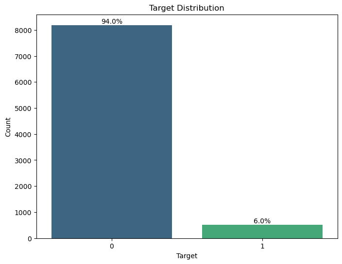

```python
%matplotlib inline
plt.figure(figsize=(8, 6))
ax = sns.countplot(data = metadata_df, x='target', palette="viridis")
total = len(metadata_df)

# Add percentage labels to the bars
for p in ax.patches:
    percentage = '{:.1f}%'.format(100 * p.get_height() / total)
    x = p.get_x() + p.get_width() / 2
    y = p.get_height()
    ax.annotate(percentage, (x, y), ha='center', va='bottom')

plt.title('Target Distribution')
plt.xlabel('Target')
plt.ylabel('Count')
plt.show()
```

```python
metadata_df['target'].value_counts()
```

```
target
0    8187
1     525
Name: count, dtype: int64
```

#### We have an imbalanced dataset with 6% positive targets (faults)

```python
train_path = f"{DATA_PATH}/train.parquet"
test_path = f"{DATA_PATH}/test.parquet"
```

```python
%%time
signals_df = pd.read_parquet(train_path, engine='fastparquet')
```

```
CPU times: total: 53.5 s
Wall time: 54.1 s
```

```python
signals_df.shape
```

```
(800000, 8712)
```

```python
sampling_rate = signals_df.shape[0]
```

### Missing Data

```python
signal_missing = signals_df.isnull().sum()
signal_missing_pct = (signal_missing / len(signals_df)) * 100

total_missing_signals = signal_missing.sum()
total_cells_signals = signals_df.shape[0] * signals_df.shape[1]
overall_missing_pct_signals = (total_missing_signals / total_cells_signals) * 100

print(f"Signal Data Shape: {signals_df.shape}")
print(f"Total Missing Values: {total_missing_signals:,}")
print(f"Total Cells: {total_cells_signals:,}")
print(f"Overall Missing Percentage: {overall_missing_pct_signals:.4f}%")
```

```
Signal Data Shape: (800000, 8712)
Total Missing Values: 0
Total Cells: 6,969,600,000
Overall Missing Percentage: 0.0000%
```

```python
signals_df.head()
```

|  | 0 | 1 | 2 | 3 | 4 | 5 | 6 | 7 | 8 | 9 | ... | 8702 | 8703 | 8704 | 8705 | 8706 | 8707 | 8708 | 8709 | 8710 | 8711 |
| --- | --- | --- | --- | --- | --- | --- | --- | --- | --- | --- | --- | --- | --- | --- | --- | --- | --- | --- | --- | --- | --- |
| 0 | 18 | 1 | -19 | -16 | -5 | 19 | -15 | 15 | -1 | -16 | ... | 18 | -22 | 12 | 8 | 13 | 6 | -21 | -15 | -9 | 20 |
| 1 | 18 | 0 | -19 | -17 | -6 | 19 | -17 | 16 | 0 | -15 | ... | 17 | -21 | 12 | 8 | 14 | 7 | -19 | -15 | -8 | 21 |
| 2 | 17 | -1 | -20 | -17 | -6 | 19 | -17 | 15 | -3 | -15 | ... | 16 | -21 | 13 | 8 | 15 | 8 | -18 | -14 | -8 | 22 |
| 3 | 18 | 1 | -19 | -16 | -5 | 20 | -16 | 16 | 0 | -15 | ... | 16 | -21 | 12 | 8 | 15 | 8 | -19 | -14 | -7 | 23 |
| 4 | 18 | 0 | -19 | -16 | -5 | 20 | -17 | 16 | -2 | -14 | ... | 17 | -22 | 12 | 8 | 15 | 8 | -18 | -14 | -8 | 23 |

5 rows × 8712 columns

### Visualizing Sample Signals

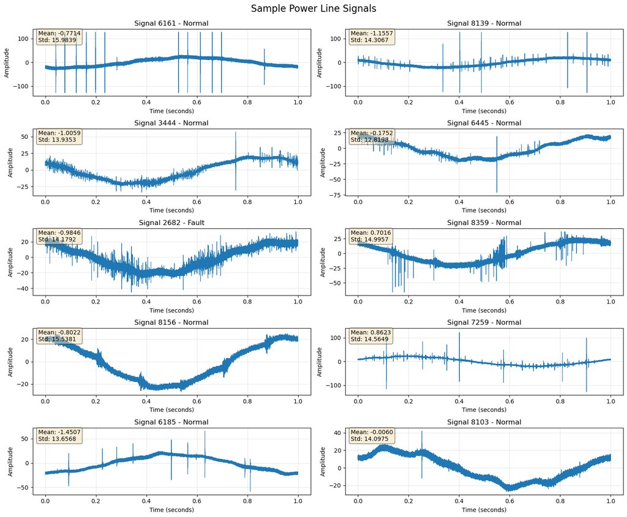

```python
n_signals = 10
signal_ids = np.random.choice(signals_df.columns, n_signals, replace=False)
time_axis = np.linspace(0, 1, len(signals_df))
fig, axes = plt.subplots(n_signals//2, 2, figsize=(15, 12))
axes = axes.flatten() if n_signals > 2 else [axes]

for i, sig_id in enumerate(signal_ids):
    if i >= len(axes):
        break

    signal_data = signals_df[str(sig_id)]

    # Get target label if available
    target_label = "Unknown"
    if metadata_df is not None and str(sig_id) in metadata_df['signal_id'].astype(str).values:
        target = metadata_df[metadata_df['signal_id'].astype(str) == str(sig_id)]['target'].iloc[0]
        target_label = "Fault" if target == 1 else "Normal"

    axes[i].plot(time_axis, signal_data, linewidth=0.8)
    axes[i].set_title(f'Signal {sig_id} - {target_label}')
    axes[i].set_xlabel('Time (seconds)')
    axes[i].set_ylabel('Amplitude')
    axes[i].grid(True, alpha=0.3)

    # Add basic stats to plot
    axes[i].text(0.02, 0.98, f'Mean: {signal_data.mean():.4f}\nStd: {signal_data.std():.4f}',
                transform=axes[i].transAxes, verticalalignment='top',
                bbox=dict(boxstyle='round', facecolor='wheat', alpha=0.5))

plt.tight_layout()
plt.suptitle('Sample Power Line Signals', y=1.02, fontsize=16)
plt.show()
```